# Chapter 3 - Classification

Now we're going to look at some classification tasks. To do so we'llbe playing around with our old friend the MNIST dataset.

## Imports

All of the imports we're going to use for the rest of the sheet are here.

```python
%matplotlib inline
from sklearn.datasets import fetch_openml
import matplotlib as mpl
import matplotlib.pyplot as plt
import numpy as np
from sklearn.linear_model import SGDClassifier
from sklearn.model_selection import cross_val_score, cross_val_predict
from sklearn.base import BaseEstimator
from sklearn.metrics import confusion_matrix, precision_score, recall_score, f1_score, precision_recall_curve, roc_curve, roc_auc_score
from sklearn.ensemble import RandomForestClassifier
from sklearn.multiclass import OneVsOneClassifier
from sklearn.preprocessing import StandardScaler
from sklearn.neighbors import KNeighborsClassifier
```

## MNIST

First we'll do a little bit of an exploration on the MNIST dataset to see what we're dealing with. Scikit-learn has some helper functions that let us download MNIST.

```python
mnist = fetch_openml('mnist_784', version=1)
mnist.keys()
```

```
dict_keys(['data', 'target', 'feature_names', 'DESCR', 'details', 'categories', 'url'])
```

Datasets loaded by scitkit in this way often have similar structures including things like the `DESCR` key which describes the dataset, `data` which contains an array with one row per instance and one column per feature, `target` containing an array with labels

```python
mnist['DESCR']
```

[output not shown]

Good ol' Yann LeCun.

Let's take a look aat what the data and target arrays look like now. They're the ones we'll be dealing with the most.

```python
X, y = mnist['data'], mnist['target']
print (X.shape)
print (y.shape)
```

```
(70000, 784)
(70000,)
```

There are 70,000 images in this dataset, and each one has 784 features. These images are 28x28 grayscale (this is where 784 comes from).

Let's take a peak at one of these images.

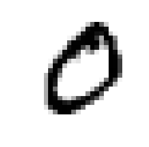

```python
some_digit = X[1]
some_digit_image = some_digit.reshape(28, 28)
plt.imshow(some_digit_image, cmap=mpl.cm.binary, interpolation="nearest")
plt.axis('off')
plt.show()
```

Looks like a human was probably trying to make a '0' here. And that should be what the label shows us.

```python
y[1]
```

```
'0'
```

Notice that for some reason this label is a string, let's get a bit ahead of the game and change these labels to integers.

```python
y = y.astype(np.uint8)
```

Now, before we go any further let's remember to split our data into a training and test set and leave our test set alone until we want to do the final validation on our data. Note that we know the training set is already shuffled, so in this case it's as simple as doing the following:

```python
X_train, X_test, y_train, y_test = X[:60000], X[60000:], y[:60000], y[60000:]
```

## Training a binary classifier

To keep the problem as simple as possible to start out, we're just going to build a classifier to identify one digit - for example: 0. Given an image it should be able to tell you if it is a 0 or not.

Let's break up our training data as such

```python
y_train_0 = (y_train == 0)
y_test_0 = (y_test == 0)
y_train_0
```

```
array([False,  True, False, ..., False, False, False])
```

We'll start with a stochastic gradient descent classifier. It handles large datasets efficiently and deals with training instances independently which makes it great for online learning (which we're not doing here, but it's good to note.)

```python
sgd_clf = SGDClassifier(random_state=42, tol=0.001)
sgd_clf.fit(X_train, y_train_0)
```

```
SGDClassifier(alpha=0.0001, average=False, class_weight=None,
       early_stopping=False, epsilon=0.1, eta0=0.0, fit_intercept=True,
       l1_ratio=0.15, learning_rate='optimal', loss='hinge', max_iter=None,
       n_iter=None, n_iter_no_change=5, n_jobs=None, penalty='l2',
       power_t=0.5, random_state=42, shuffle=True, tol=0.001,
       validation_fraction=0.1, verbose=0, warm_start=False)
```

Now we can use it to classify images of the number 0.

```python
sgd_clf.predict([some_digit])
```

```
array([ True])
```

Looks like it worked for this case! Now thet's evaluate our models overall performance.

## Performance Measures

It can be a lot trickier to evaluate a classifier than a regressor.

### Cross-validation

Similar to how we did for regression let's use K-fold cross validation to evaluate the model.

```python
cross_val_score(sgd_clf, X_train, y_train_0, cv=3, scoring='accuracy')
```

```
array([0.98665067, 0.98125   , 0.98729936])
```

Over 97% accuracy seems pretty good. However, let's look at an extremely dumb classifier that just puts everything in the not-0 class.

```python
class Never0Classifier(BaseEstimator):
  def fit(self, X, y=None):
    pass
  def predict(self, X):
    return np.zeros((len(X), 1), dtype=bool)

never_0_clf = Never0Classifier()
cross_val_score(never_0_clf, X_train, y_train_0, cv=3, scoring='accuracy')
```

```
array([0.9003 , 0.9035 , 0.90005])
```

Over 90% accuracy even though all we're doing is just automatically predicting something is not a 0. This makes sense with a complete random selection of digits, we'd expect 1/10 to be a 0.

This demonstrates that maybe accuracy isn't the measure when we're working with skewed datasets (some classes are much more frequent than others).

### Confusion Matrix

A confusion matrix is a much better way to evaluate the performance of a classifier. A CM will tell us how often something with a Class A is predicted to be Class B.

To compute the confusion matrix we first need to have a set of predictions. Let's get that using the `cross_val_predict` function. This returns cross-validation predictions instead of evaluation scores.

```python
y_train_pred = cross_val_predict(sgd_clf, X_train, y_train_0, cv=3)
```

Now we just pass these predictions to the confusion matrix function as well as the actual target classes.

```python
confusion_matrix(y_train_0, y_train_pred)
```

```
array([[53406,   671],
       [  225,  5698]])
```

A perfect classifier would have only true positives and true negatives and would have non-zeroes on it's main diagonal

```python
y_train_perfect_predictions = y_train_0
confusion_matrix(y_train_0, y_train_perfect_predictions)
```

```
array([[54077,     0],
       [    0,  5923]])
```

A confusion matrix gives you a lot of data but sometimes you may prefer a more concise metric. One of these it called *precision* it is the accuracy of the positive predictions.

$precision = \frac{TP}{TP+FP}$

TP is the number of true positives and FP is the number of false positives.

We can have perfect precision by maaking one single correct positive prediction. So precision is generally used alongside another metric called *recall*, sometimes called *sensitivity* or *true positive rate*.

$recall = \frac{TP}{TP+FN}$

### Precision and Recall

Scikit gives us a way to computer a bunch of different classifier metrics.

```python
print(precision_score(y_train_0, y_train_pred))
print(recall_score(y_train_0, y_train_pred))
```

```
0.8946459412780656
0.962012493668749
```

It is sometimes convenient to combine precision and recall into a single metrics that we call the $F_1$ score. It is the *harmonic mean* of precision and recall. The regular mean treats all values equally, but the harmonix mean gives much more weight to lower values. So the classifier only gets a high $F_1$ score if both precision and recall are high.

$F_1 = \frac{2}{\frac{1}{precision} + \frac{1}{recall}} = 2 \times \frac{precision\times recall}{precision+recall} = \frac{TP}{TP+\frac{FN+FP}{2}}$

```python
f1_score(y_train_0, y_train_pred)
```

```
0.9271070615034169
```

### Precision/Recall Tradeoff

Increasing precision on a model will reduce it's recall and vice versa.

To understand this let's look at how the `SGDClaassifier` makes its classification decisions. For each instance the model computes a score based on a *decision function* if that score is greater than a threshold isassigns the instance to a positive class, otherwise it assigns it to a negative class. If you increase this threshold the precision goes up, but the recall goes down and vice versa.

Sklearn doesn't let you set the threshold directly, but it gives you access to the decision scores used to make the predictions.

```python
y_scores = sgd_clf.decision_function([some_digit])
y_scores
```

```
array([24459.81485278])
```

You can then compare this to any threshold that you'd like. By default SGDClassifier uses a threshold of 0. So the following code returns the same as the predict function.

```python
threshold = 0
(y_scores > threshold)
```

```
array([ True])
```

We can raise this threshold if we'd like.

```python
threshold = 600000
(y_scores > threshold)
```

```
array([False])
```

How do we decide the threshold to use? First we need to get the scores of all instances.

```python
y_scores = cross_val_predict(sgd_clf, X_train, y_train_0, cv=3, method="decision_function")
```

With these scores, we can now computer the precision/recall for all possible thresholds.

```python
precisions, recalls, thresholds = precision_recall_curve(y_train_0, y_scores)
```

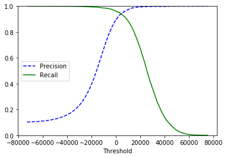

```python
def plot_precision_recall_vs_threshold(precisions, recalls, thresholds):
  plt.plot(thresholds, precisions[:-1], 'b--', label='Precision')
  plt.plot(thresholds, recalls[:-1], 'g-', label='Recall')
  plt.xlabel('Threshold')
  plt.legend(loc='center left')
  plt.ylim([0,1])
plot_precision_recall_vs_threshold(precisions, recalls, thresholds)
plt.show()
```

Looking at this you can now choose a threshold that gives you a high precision or high threshold base on what your task needs.

### The ROC Curve

The reciever operating characteristic is another common tool used on binary classifiers. Instead of plotting precision v. recall it plots the true positive rate v. the false positive rate.

```python
fpr, tpr, thresholds = roc_curve(y_train_0, y_scores)
```

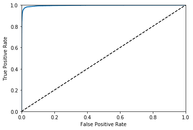

```python
def plot_roc_curve(fpr, tpr, label=None):
  plt.plot(fpr, tpr, linewidth=2, label=label)
  plt.plot([0, 1], [0, 1], 'k--')
  plt.axis([0, 1, 0, 1])
  plt.xlabel('False Positive Rate')
  plt.ylabel('True Positive Rate')
plot_roc_curve(fpr, tpr)
plt.show()
```

The higher the TPR the more false positives the classifier produces. A purely random classifier would be on the dotted line. A good classifier stays as far as possible from that line.

We can compare classifiers by measuring the *area under curve* (AUC) here.

```python
roc_auc_score(y_train_0, y_scores)
```

```
0.9958314110483667
```

A perfect classifier would have an AUC=1 and a purely random classifier would have AUC=5.

Let's train a RandomForestClassifier and compare these to the SGDClassifier.

```python
forest_clf = RandomForestClassifier(random_state=42, n_estimators=10)
y_probas_forest = cross_val_predict(forest_clf, X_train, y_train_0, cv=3, method="predict_proba")
```

Of course, we need scores not probabilities. We'll use the positive class's probability as the score.

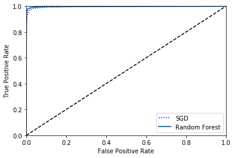

```python
y_scores_forest = y_probas_forest[:, 1]  #  score = prob of positive class
fpr_forest, tpr_forest, thresholds_forest = roc_curve(y_train_0, y_scores_forest)
plt.plot(fpr, tpr, 'b:', label='SGD')
plot_roc_curve(fpr_forest, tpr_forest, "Random Forest")
plt.legend(loc='lower right')
plt.show()
```

It looks like the random forest classifier is just slightly better than the SGD classifier.

```python
roc_auc_score(y_train_0, y_scores_forest)
```

```
0.9970117850007284
```

## Multiclass Classification

So far we've only been playing with binary classifiers. Technically with this knowledge we could make a multiclass classifier by just creating 10 binary classifiers (one for each digit). Then you would just pick the one with the highest score. We call this a one-versus-all classifier.

You could also train a classifier for every pair of digits. One to distinguish 0's and 1's, another for 0's and 2's etc. We call this a one-versus-one classifier. The main advantage of this type of classifier is that you only need to train it on a subset of the training set.

Some algorithms (such as SVMs) scale poorly with the size of the training set, so an OvO classifier is preferred. But for most others an OvA would be preferred.

SciKit learn detect when you try to use a binary classifier for multiclass classifications and and automagically runs OvA (unless you're doing SVM).

Let's give it a shot.

```python
sgd_clf.fit(X_train, y_train)
sgd_clf.predict([some_digit])
```

```
array([0], dtype=uint8)
```

Under the hood, Sklearn has trained 10 binary classifiers, got the decision scores for the image and then selected the class with the highest score. We can see that this is the case by looking at the decision function and seeing that it returns the 10 scores, one per class:

```python
some_digit_scores = sgd_clf.decision_function([some_digit])
some_digit_scores
```

```
array([[ 24459.81485278, -40634.1635967 , -13261.20205235,
         -7424.19339601, -16457.07676602, -15974.85481158,
        -15723.27000254, -19579.59896354,  -3040.27913941,
         -7174.06150875]])
```

Pretty easy to see here that it selected the right one.

You can also force Sklearn to use an OvO classifier or an OvA classifier.

```python
ovo_clf = OneVsOneClassifier(SGDClassifier(random_state=42, tol=0.001))
ovo_clf.fit(X_train, y_train)
ovo_clf.predict([some_digit])
```

```
array([0], dtype=uint8)
```

Training a random forest classifier is just as easy.

```python
forest_clf.fit(X_train, y_train)
forest_clf.predict([some_digit])
```

```
array([0], dtype=uint8)
```

But this time Sklearn didn't need to run OvA or OvO because RF can directly classify into multiple classes. You can see the probablities it assigned to each class:

```python
forest_clf.predict_proba([some_digit])
```

```
array([[1., 0., 0., 0., 0., 0., 0., 0., 0., 0.]])
```

RF is 100% confident that this digit is a 0. That's pretty good. Now, of course, we should evaluate the classifier.

```python
cross_val_score(sgd_clf, X_train, y_train, cv=3, scoring="accuracy")
```

```
array([0.8489802 , 0.87129356, 0.86988048])
```

It gets over 84% accuracy on the three test folds. Completely random would be 10%, so this isn't so bad.

But, we might be able to improve on this by doing something as simple as scaling the inputs. These sorts of things make a difference!

```python
scaler = StandardScaler()
X_train_scaled = scaler.fit_transform(X_train.astype(np.float64))
cross_val_score(sgd_clf, X_train_scaled, y_train, cv=3, scoring="accuracy")
```

```
array([0.89707059, 0.8960948 , 0.90693604])
```

Look at that! It's a little bit closer to 90% now!

## Error Analysis

If we were working on a real project we'd spend some more time exploring different models, hyper-parameter tuning the best onces, automating things, etc. Once you find a promising model you want to find ways to improve it. One way of doing this is evaluating the errors that is makes.

First, you can look at the confusion matrix.

```python
y_train_pred = cross_val_predict(sgd_clf, X_train_scaled, y_train, cv=3)
```

```python
conf_mx = confusion_matrix(y_train, y_train_pred)
conf_mx
```

```
array([[5578,    0,   22,    7,    8,   45,   35,    5,  222,    1],
       [   0, 6410,   35,   26,    4,   44,    4,    8,  198,   13],
       [  28,   27, 5232,  100,   74,   27,   68,   37,  354,   11],
       [  23,   18,  115, 5254,    2,  209,   26,   38,  373,   73],
       [  11,   14,   45,   12, 5219,   11,   33,   26,  299,  172],
       [  26,   16,   31,  173,   54, 4484,   76,   14,  482,   65],
       [  31,   17,   45,    2,   42,   98, 5556,    3,  123,    1],
       [  20,   10,   53,   27,   50,   13,    3, 5696,  173,  220],
       [  17,   64,   47,   91,    3,  125,   24,   11, 5421,   48],
       [  24,   18,   29,   67,  116,   39,    1,  174,  329, 5152]])
```

Probably easier to look at this as an image.

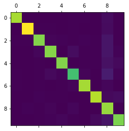

```python
plt.matshow(conf_mx)
plt.show()
```

Looks good. Most of the stuff on the main diagnoal is lit up, which means things were predicted correctly. Let's just focus on the errors to see where mistakes are common.

First we'll divide ever value in the confusion matrix by the number of images in each class. This just makes sure that we treat all classes fairly independent of how many of each there are.

```python
row_sums = conf_mx.sum(axis=1, keepdims=True)
norm_conf_mx = conf_mx / row_sums
```

Now fill the diagonal with zero and only keep the errors.

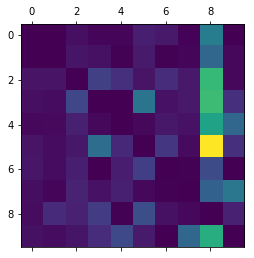

```python
np.fill_diagonal(norm_conf_mx, 0)
plt.matshow(norm_conf_mx)
plt.show()
```

We can tell that a lot of things are being misclassifed as 8's. Especially 5's. A reasonable thing to do from here would be to plot the instances that are confusing the classifier, then try to see how we might be able to improve them.

## Multilabel Classification

So far we've been dealing with instances that have been assigned a single class. But there are some cases where we might want a multiple classes for each instance. i.e., if we have a facial recognation system it should output multiple results if it recognizes more than one person.

Let's do something a bit simpler than this for illustrative purposes.

```python
y_train_large = (y_train >= 7)
y_train_even = (y_train % 2 == 0)
y_multilabel = np.c_[y_train_large, y_train_even]

knn_clf = KNeighborsClassifier()
knn_clf.fit(X_train, y_multilabel)
```

```
KNeighborsClassifier(algorithm='auto', leaf_size=30, metric='minkowski',
           metric_params=None, n_jobs=None, n_neighbors=5, p=2,
           weights='uniform')
```

We've created a `y_multilabel` array with two target labels for each digit. One indicating if a digit is large and another indicating if a digit is even. Obviously 8 falls into both of these categories

Now let's make a prediction and see what we get.

```python
knn_clf.predict([some_digit])
```

```
array([[False,  True]])
```